# Part II - Ford GoBike System Data Explanation

## by Khoa Pham

## Investigation Overview

> Finding the pattern usage of different type of user for better understanding their behavior on different time dimensions.

## Dataset Overview

> The dataset is included 2,407,259 records of bike trips of BayWheel Sanfrancisco in 2019. After enriching features, the dataset has total 20 columns. There are one main category feature, that is `user_type` (Subscriber or Customer).

## Distribution of trip duration in minutes of Subscriber & Customer

Customer trip duration distribution is typically from 10 to 20 minutes that is longer than subscribers whose ride mostly is from 8 minutes to 10 minutes.

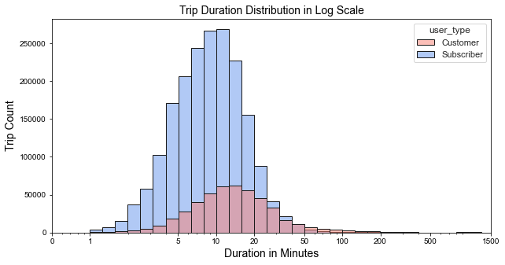

## The relative percentage of trip between Subscriber & Customer

There are 80.38% of the trip are taken by subscriber and customer's trip percentage is 19.62%.

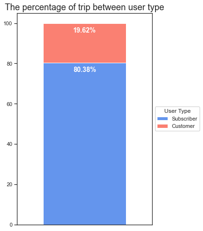

## The relative percentage of trip between weekend & weekday

There are 82.5% of the trip conducted on weekday rather than weekend.

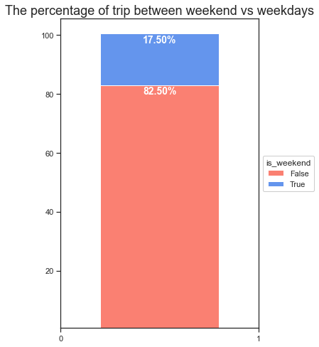

## The comparison of average trip duration in minutes between Subscriber & Cusomter

The number of trips conducted by customer is smaller than subscriber, but their average trip duration (22 minutes) is double to subscriber (11 minutes).

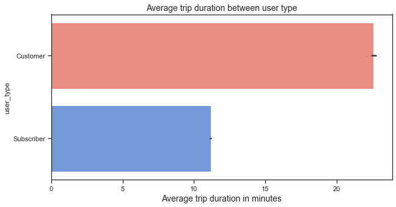

## The average trip duration in minutes changing over the week

The average trip duration in 2019 is 13.41 min. The number of trips on Saturday & Sunday is lower compared to other days. However, there is a big difference in the trip duration on weekends. People tend to ride longer about 4-5 minutes than weekdays.

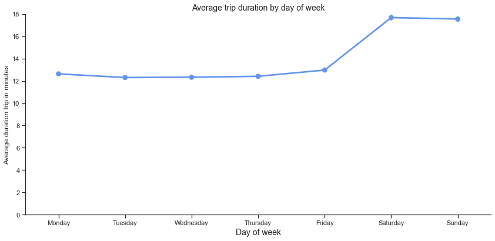

## The trip distribution over the month between Subscriber & Customer

Overall, the subscriber contributes the greatest number of the trip over the months of 2019. However, in December, trip count's customer is higher than subscriber. This could be because of the holiday season so our regular bikers are not going to commute to work (perhaps they take annual leaves) rather than the customer could be tourists or travelers from outside of the city.

The month of using for subscriber is in March and April. After that the number of trips is dropping as coming to summertime and come back on springtime (September & October). And it significant dops on holiday season when most of office workers is taking time off from work and not commuting to work.

On the other hand, customer starts using more bikes from September till end of the year.

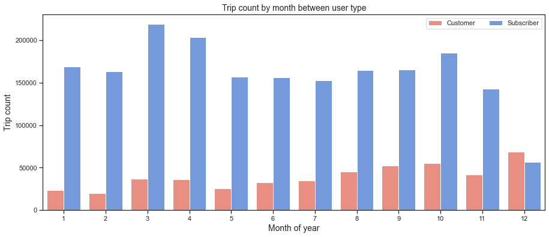

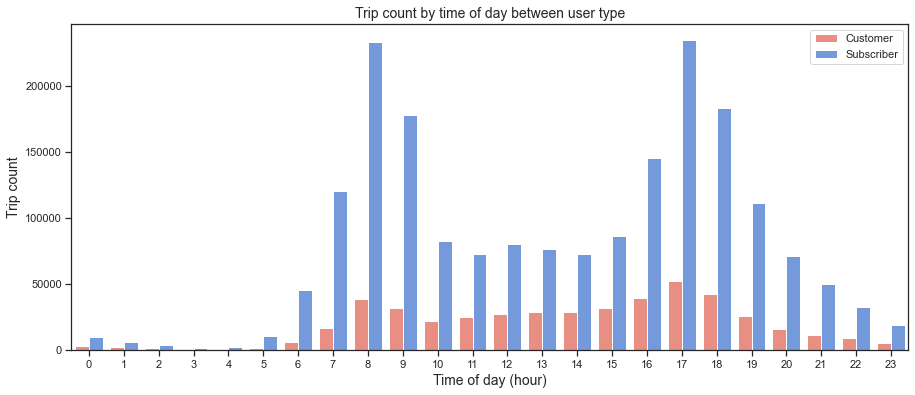

## The heatmap of average trip duration in minutes over the time of day & day of week of Customer & Subscriber

In overall, the customer rider has the average trip duration longer than the subscriber as stated in the color density of customer is darker for the whole-time frame of the day and 7 days of the week. Customers focus the trip on daytime of weekends. There is some significant average trip duration of early morning that could be the fewer trip taken during that time. The focus on daytime from 10am till 6pm and on weekend to promote on weekend trip fun for the riders to getting to push the bike utilization on weekends. For Subscriber, almost the average trip duration is the same over the time of day and 7 days of the week. This could be different behavior from customer who could the tourists or travelers to get more time on rides rather than office employees who commute to work and finish the trip as soon as possible.

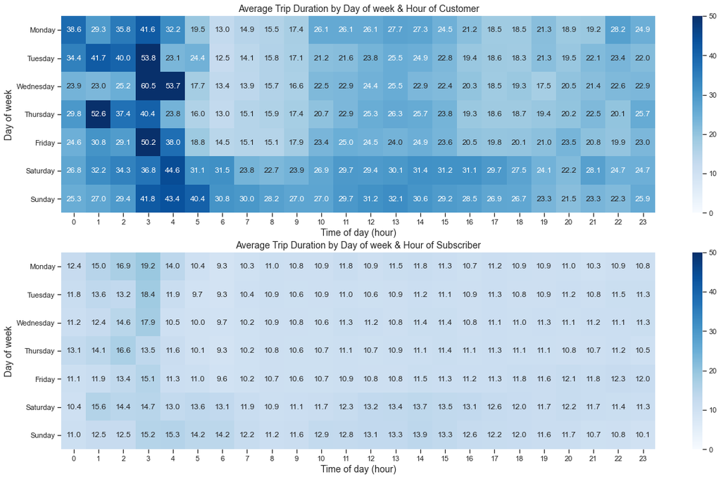

## The heatmap of number of trip over the time of day & day of week of Customer & Subscriber

The heatmap clearly shows that customer use the bike on weekend (10am to 5pm) and weekday on 8am and it is getting denser on 5-6pm on weekdays. On the other hand, the subscriber uses the bike mostly on weekdays on 8am and 5pm. But in overall, the number of trips taken of subscriber is far higher than customer as the cooler color of customer.

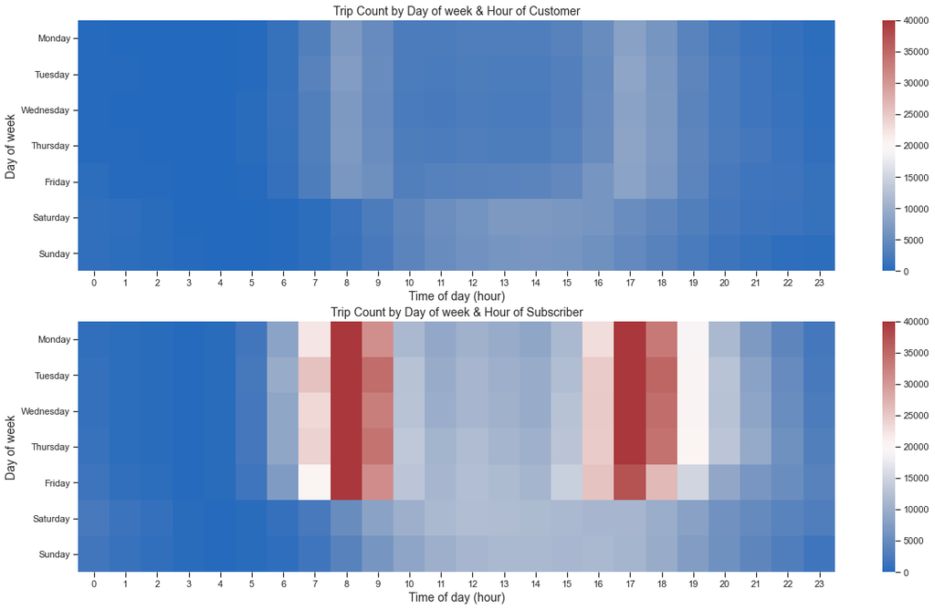

## The heatmap of average trip duration in minutes over the day of week & month of Customer & Subscriber

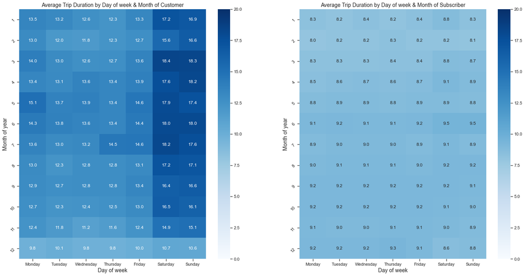

## The heatmap of number of trip over the day of week & month of Customer & Subscriber

The heatmap shows most of the trip taken over the year of subscriber is on Monday to Friday and from January to November with the peaks Fridays of March, Tuesdays of April, and Tuesdays of October and the number significant drops in December. In contrast, the customer is getting hot in December from Monday till Friday. That is a bit surprising insight that we can customize the promoting and bike utilization based on the pattern usage of user type on different time dimensions.

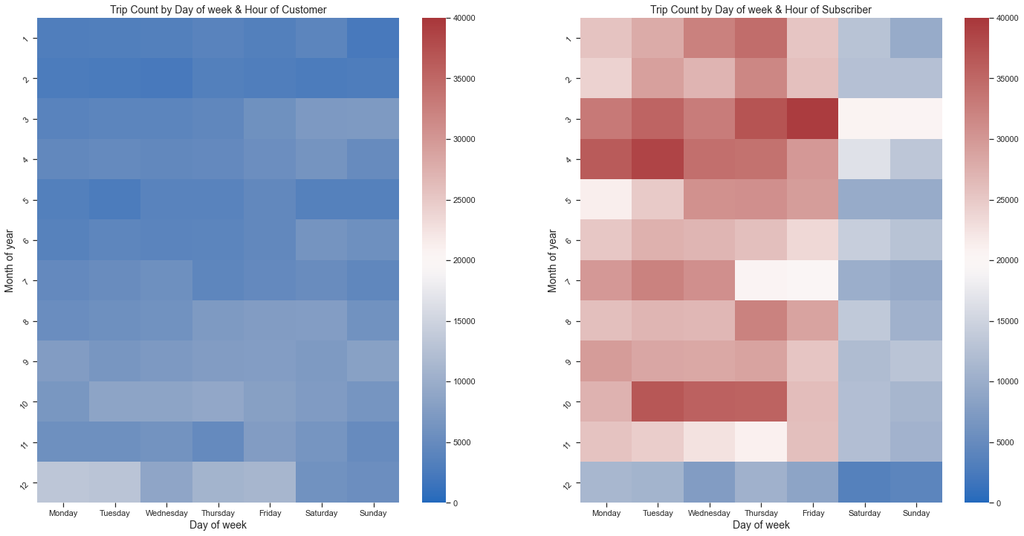